# Twitter US Airline Sentiment Analysis

### Background

Twitter possesses 330 million monthly active users, which allows businesses to reach a broad population and connect with customers without intermediaries. On the other hand, there’s so much information that it’s difficult for brands to quickly detect negative social mentions that could harm their business.

That's why sentiment analysis/classification, which involves monitoring emotions in conversations on social media platforms, has become a key strategy in social media marketing.

##### Objective:

Listening to how customers feel about the product/service on Twitter allows companies to understand their audience, keep on top of what’s being said about their brand and their competitors, and discover new trends in the industry.

### Data Context

A sentiment analysis job about the problems of each major U.S. airline. Twitter data was scraped from February of 2015 and contributors were asked to first classify positive, negative, and neutral tweets, followed by categorizing negative reasons (such as "late flight" or "rude service").

1. tweet_id
2. airline_sentiment
3. airline_sentiment_confidence
4. negativereason
5. negativereason_confidence
6. airline
7. airline_sentiment_gold
8. name
9. negativereason_gold
10. retweet_count
11. text
12. tweet_coord
13. tweet_created
14. tweet_location
15. user_timezone

#### Importing all the required packages for the project:

```python
# install and import necessary libraries.
import re, string, unicodedata                          # Import Regex, string and unicodedata.
import contractions                                     # Import contractions library.
from bs4 import BeautifulSoup                           # Import BeautifulSoup.
import numpy as np                                      # Import numpy.
import pandas as pd                                     # Import pandas.
import nltk                                             # Import Natural Language Tool-Kit.
# Download Stopwords.
nltk.download('punkt')
nltk.download('wordnet')
from nltk.corpus import stopwords                       # Import stopwords.
from nltk.tokenize import word_tokenize, sent_tokenize  # Import Tokenizer.
from nltk.stem.wordnet import WordNetLemmatizer         # Import Lemmatizer.
import matplotlib.pyplot as plt
import seaborn as sns
import matplotlib.pyplot as plt
# Ignore the warnings
import warnings
warnings.filterwarnings("ignore")
# Vectorization (Convert text data to numbers).
from sklearn.feature_extraction.text import CountVectorizer
from sklearn.model_selection import KFold , StratifiedKFold, cross_val_score
from sklearn.metrics import accuracy_score
import seaborn as sns
from sklearn.ensemble import RandomForestClassifier       # Import Random forest Classifier
from sklearn.metrics import classification_report         # Import Classification report
from sklearn.model_selection import cross_val_score
# Using TfidfVectorizer to convert text data to numbers.
from sklearn.feature_extraction.text import TfidfVectorizer
```

#### Read in the dataset using pandas

```python
# importing dataset stored in csv file and setting 1st cloumn as index
df = pd.read_csv(
    r"C:\Users\user\Desktop\AI_ML_Austin\notebook prog files\ProjectWork9\Tweets.csv"
)
# creating a copy of the data so that original data remains unchanged
tweetsdf1 = df.copy()
```

#### To assess the data set (Top 10)

```python
tweetsdf1.head(10)  # display top 10 rows
```

|  | tweet_id | airline_sentiment | airline_sentiment_confidence | negativereason | negativereason_confidence | airline | airline_sentiment_gold | name | negativereason_gold | retweet_count | text | tweet_coord | tweet_created | tweet_location | user_timezone |
| --- | --- | --- | --- | --- | --- | --- | --- | --- | --- | --- | --- | --- | --- | --- | --- |
| 0 | 570306133677760513 | neutral | 1.0000 | NaN | NaN | Virgin America | NaN | cairdin | NaN | 0 | @VirginAmerica What @dhepburn said. | NaN | 2015-02-24 11:35:52 -0800 | NaN | Eastern Time (US & Canada) |
| 1 | 570301130888122368 | positive | 0.3486 | NaN | 0.0000 | Virgin America | NaN | jnardino | NaN | 0 | @VirginAmerica plus you've added commercials t... | NaN | 2015-02-24 11:15:59 -0800 | NaN | Pacific Time (US & Canada) |
| 2 | 570301083672813571 | neutral | 0.6837 | NaN | NaN | Virgin America | NaN | yvonnalynn | NaN | 0 | @VirginAmerica I didn't today... Must mean I n... | NaN | 2015-02-24 11:15:48 -0800 | Lets Play | Central Time (US & Canada) |
| 3 | 570301031407624196 | negative | 1.0000 | Bad Flight | 0.7033 | Virgin America | NaN | jnardino | NaN | 0 | @VirginAmerica it's really aggressive to blast... | NaN | 2015-02-24 11:15:36 -0800 | NaN | Pacific Time (US & Canada) |
| 4 | 570300817074462722 | negative | 1.0000 | Can't Tell | 1.0000 | Virgin America | NaN | jnardino | NaN | 0 | @VirginAmerica and it's a really big bad thing... | NaN | 2015-02-24 11:14:45 -0800 | NaN | Pacific Time (US & Canada) |
| 5 | 570300767074181121 | negative | 1.0000 | Can't Tell | 0.6842 | Virgin America | NaN | jnardino | NaN | 0 | @VirginAmerica seriously would pay $30 a fligh... | NaN | 2015-02-24 11:14:33 -0800 | NaN | Pacific Time (US & Canada) |
| 6 | 570300616901320704 | positive | 0.6745 | NaN | 0.0000 | Virgin America | NaN | cjmcginnis | NaN | 0 | @VirginAmerica yes, nearly every time I fly VX... | NaN | 2015-02-24 11:13:57 -0800 | San Francisco CA | Pacific Time (US & Canada) |
| 7 | 570300248553349120 | neutral | 0.6340 | NaN | NaN | Virgin America | NaN | pilot | NaN | 0 | @VirginAmerica Really missed a prime opportuni... | NaN | 2015-02-24 11:12:29 -0800 | Los Angeles | Pacific Time (US & Canada) |
| 8 | 570299953286942721 | positive | 0.6559 | NaN | NaN | Virgin America | NaN | dhepburn | NaN | 0 | @virginamerica Well, I didn't…but NOW I DO! :-D | NaN | 2015-02-24 11:11:19 -0800 | San Diego | Pacific Time (US & Canada) |
| 9 | 570295459631263746 | positive | 1.0000 | NaN | NaN | Virgin America | NaN | YupitsTate | NaN | 0 | @VirginAmerica it was amazing, and arrived an ... | NaN | 2015-02-24 10:53:27 -0800 | Los Angeles | Eastern Time (US & Canada) |

Checking random rows

```python
np.random.seed(
    1
)  # random set with seed 1, so the same set of random values can be generated everytime
tweetsdf1.sample(n=20)  # Print 20 random rows to check the dataset
```

|  | tweet_id | airline_sentiment | airline_sentiment_confidence | negativereason | negativereason_confidence | airline | airline_sentiment_gold | name | negativereason_gold | retweet_count | text | tweet_coord | tweet_created | tweet_location | user_timezone |
| --- | --- | --- | --- | --- | --- | --- | --- | --- | --- | --- | --- | --- | --- | --- | --- |
| 8515 | 568198336651649027 | positive | 1.0000 | NaN | NaN | Delta | NaN | GenuineJack | NaN | 0 | @JetBlue I'll pass along the advice. You guys ... | NaN | 2015-02-18 16:00:14 -0800 | Massachusetts | Central Time (US & Canada) |
| 3439 | 568438094652956673 | negative | 0.7036 | Lost Luggage | 0.7036 | United | NaN | vina_love | NaN | 0 | @united I sent you a dm with my file reference... | NaN | 2015-02-19 07:52:57 -0800 | ny | Quito |
| 6439 | 567858373527470080 | positive | 1.0000 | NaN | NaN | Southwest | NaN | Capt_Smirk | NaN | 0 | @SouthwestAir Black History Commercial is real... | NaN | 2015-02-17 17:29:21 -0800 | La Florida | Eastern Time (US & Canada) |
| 5112 | 569336871853170688 | negative | 1.0000 | Late Flight | 1.0000 | Southwest | NaN | scoobydoo9749 | NaN | 0 | @SouthwestAir why am I still in Baltimore?! @d... | [39.1848041, -76.6787131] | 2015-02-21 19:24:22 -0800 | Tallahassee, FL | America/Chicago |
| 5645 | 568839199773732864 | positive | 0.6832 | NaN | NaN | Southwest | NaN | laurafall | NaN | 0 | @SouthwestAir SEA to DEN. South Sound Volleyba... | NaN | 2015-02-20 10:26:48 -0800 | NaN | Pacific Time (US & Canada) |
| 1380 | 569748884164988929 | negative | 1.0000 | Flight Attendant Complaints | 0.6818 | United | NaN | JacquieMae08 | NaN | 1 | @united One of your workers refused to give me... | NaN | 2015-02-22 22:41:34 -0800 | SD \|\| CA | Arizona |
| 12674 | 570066226233417728 | negative | 1.0000 | Bad Flight | 0.6966 | American | NaN | lczand | NaN | 0 | @AmericanAir seats that were assigned are inap... | NaN | 2015-02-23 19:42:34 -0800 | SE USA | Central Time (US & Canada) |
| 13475 | 569853969469734912 | negative | 1.0000 | Customer Service Issue | 0.3642 | American | NaN | Davitossss | NaN | 0 | @AmericanAir now you change my gate and don't ... | NaN | 2015-02-23 05:39:08 -0800 | NaN | NaN |
| 9630 | 569771270839013376 | negative | 1.0000 | Late Flight | 1.0000 | US Airways | NaN | jakenemmasmom | NaN | 0 | @USAirways What a mess caused by the computer ... | NaN | 2015-02-23 00:10:31 -0800 | NaN | NaN |
| 3745 | 568157451729526784 | negative | 1.0000 | Customer Service Issue | 0.6803 | United | NaN | HeHaithMe | NaN | 1 | @united How come you are the ONLY airline, of ... | NaN | 2015-02-18 13:17:47 -0800 | Born/Raised in 314/Home is 317 | Eastern Time (US & Canada) |
| 9961 | 569600023597428736 | negative | 1.0000 | longlines | 1.0000 | US Airways | NaN | RBuchmann | NaN | 0 | @USAirways Its pretty ridiculous that at PHX s... | NaN | 2015-02-22 12:50:02 -0800 | Saint Louis, MO | Central Time (US & Canada) |
| 2398 | 569228892638019585 | negative | 1.0000 | Cancelled Flight | 1.0000 | United | NaN | pwaggs | NaN | 0 | @united yes 1427 Cancelled Flightled. Moved to... | NaN | 2015-02-21 12:15:18 -0800 | Washington, DC | Eastern Time (US & Canada) |
| 13431 | 569865061855932416 | negative | 1.0000 | Cancelled Flight | 0.6501 | American | NaN | Mj_Effects | NaN | 0 | @AmericanAir this is the biggest joke of #cust... | NaN | 2015-02-23 06:23:12 -0800 | Manhattan, NY | Eastern Time (US & Canada) |
| 14159 | 569660029093203968 | negative | 1.0000 | Cancelled Flight | 0.3576 | American | NaN | TheJoshAbides | NaN | 0 | @AmericanAir I made my flight but then still h... | NaN | 2015-02-22 16:48:29 -0800 | New York City | Eastern Time (US & Canada) |
| 4097 | 567823707160354816 | negative | 1.0000 | Bad Flight | 0.6616 | United | NaN | uncmnwellness | NaN | 1 | @united how can you not know the weight of our... | NaN | 2015-02-17 15:11:36 -0800 | Ventura, California | Pacific Time (US & Canada) |
| 12866 | 569997196298293249 | neutral | 1.0000 | NaN | NaN | American | NaN | jetsetterprob | NaN | 0 | @AmericanAir #epicfail on connections in #Chic... | NaN | 2015-02-23 15:08:16 -0800 | Brooklyn to Across the Globe | NaN |
| 6619 | 567754223362666496 | negative | 1.0000 | Bad Flight | 1.0000 | Southwest | NaN | LedPinkCloudz | NaN | 0 | @SouthwestAir in my 30 years of flying I have ... | NaN | 2015-02-17 10:35:29 -0800 | Las Vegas, NV | Pacific Time (US & Canada) |
| 6597 | 567764034418909186 | positive | 1.0000 | NaN | NaN | Southwest | NaN | DebMannRN | NaN | 0 | @SouthwestAir Another great flight &amp; crew,... | NaN | 2015-02-17 11:14:29 -0800 | Indy | Eastern Time (US & Canada) |
| 5721 | 568779480019251201 | negative | 1.0000 | Bad Flight | 0.6872 | Southwest | NaN | rebekahcancino | NaN | 0 | @SouthwestAir The in-browser hover over is int... | NaN | 2015-02-20 06:29:30 -0800 | PHX, AZ | Arizona |
| 6261 | 568090175122907136 | negative | 1.0000 | Late Flight | 1.0000 | Southwest | NaN | oliviasdad1 | NaN | 0 | @SouthwestAir now it's delayed until 3:55. Get... | NaN | 2015-02-18 08:50:27 -0800 | NaN | NaN |

The dataset looks consistent with the description provided in the Data Dictionary

#### Check the shape of the provided data

```python
print(
    f"There are {tweetsdf1.shape[0]} rows and {tweetsdf1.shape[1]} columns."
)  # f-string
```

```
There are 14640 rows and 15 columns.
```

#### Check datatype count

```python
tweetsdf1.dtypes.value_counts()  # Gives count of the different datatype in dataset
```

```
object     11
float64     2
int64       2
dtype: int64
```

#### Get the complete info of the dataset

```python
tweetsdf1.info()  # display complete info
```

```
<class 'pandas.core.frame.DataFrame'>
RangeIndex: 14640 entries, 0 to 14639
Data columns (total 15 columns):
 #   Column                        Non-Null Count  Dtype
---  ------                        --------------  -----
 0   tweet_id                      14640 non-null  int64
 1   airline_sentiment             14640 non-null  object
 2   airline_sentiment_confidence  14640 non-null  float64
 3   negativereason                9178 non-null   object
 4   negativereason_confidence     10522 non-null  float64
 5   airline                       14640 non-null  object
 6   airline_sentiment_gold        40 non-null     object
 7   name                          14640 non-null  object
 8   negativereason_gold           32 non-null     object
 9   retweet_count                 14640 non-null  int64
 10  text                          14640 non-null  object
 11  tweet_coord                   1019 non-null   object
 12  tweet_created                 14640 non-null  object
 13  tweet_location                9907 non-null   object
 14  user_timezone                 9820 non-null   object
dtypes: float64(2), int64(2), object(11)
memory usage: 1.7+ MB
```

#### Describe all columns

```python
tweetsdf1.describe(
    include="all"
).T  #describe all dataset. Use transpose so column wise details can be view from top to bottom
```

|  | count | unique | top | freq | mean | std | min | 25% | 50% | 75% | max |
| --- | --- | --- | --- | --- | --- | --- | --- | --- | --- | --- | --- |
| tweet_id | 14640 | NaN | NaN | NaN | 5.69218e+17 | 7.79111e+14 | 5.67588e+17 | 5.68559e+17 | 5.69478e+17 | 5.6989e+17 | 5.70311e+17 |
| airline_sentiment | 14640 | 3 | negative | 9178 | NaN | NaN | NaN | NaN | NaN | NaN | NaN |
| airline_sentiment_confidence | 14640 | NaN | NaN | NaN | 0.900169 | 0.16283 | 0.335 | 0.6923 | 1 | 1 | 1 |
| negativereason | 9178 | 10 | Customer Service Issue | 2910 | NaN | NaN | NaN | NaN | NaN | NaN | NaN |
| negativereason_confidence | 10522 | NaN | NaN | NaN | 0.638298 | 0.33044 | 0 | 0.3606 | 0.6706 | 1 | 1 |
| airline | 14640 | 6 | United | 3822 | NaN | NaN | NaN | NaN | NaN | NaN | NaN |
| airline_sentiment_gold | 40 | 3 | negative | 32 | NaN | NaN | NaN | NaN | NaN | NaN | NaN |
| name | 14640 | 7701 | JetBlueNews | 63 | NaN | NaN | NaN | NaN | NaN | NaN | NaN |
| negativereason_gold | 32 | 13 | Customer Service Issue | 12 | NaN | NaN | NaN | NaN | NaN | NaN | NaN |
| retweet_count | 14640 | NaN | NaN | NaN | 0.0826503 | 0.745778 | 0 | 0 | 0 | 0 | 44 |
| text | 14640 | 14427 | @united thanks | 6 | NaN | NaN | NaN | NaN | NaN | NaN | NaN |
| tweet_coord | 1019 | 832 | [0.0, 0.0] | 164 | NaN | NaN | NaN | NaN | NaN | NaN | NaN |
| tweet_created | 14640 | 14247 | 2015-02-24 09:54:34 -0800 | 5 | NaN | NaN | NaN | NaN | NaN | NaN | NaN |
| tweet_location | 9907 | 3081 | Boston, MA | 157 | NaN | NaN | NaN | NaN | NaN | NaN | NaN |
| user_timezone | 9820 | 85 | Eastern Time (US & Canada) | 3744 | NaN | NaN | NaN | NaN | NaN | NaN | NaN |

```python
#Distinct values
tweetsdf1['airline_sentiment'].nunique()
```

```
3
```

```python
(tweetsdf1.airline_sentiment.value_counts())/(tweetsdf1.airline_sentiment.count())
```

```
negative    0.626913
neutral     0.211680
positive    0.161407
Name: airline_sentiment, dtype: float64
```

There is imbalance between negative, neutral and Positive values

```python
tweetsdf1.isnull().sum(axis=0)          # Check for NULL values.
```

```
tweet_id                            0
airline_sentiment                   0
airline_sentiment_confidence        0
negativereason                   5462
negativereason_confidence        4118
airline                             0
airline_sentiment_gold          14600
name                                0
negativereason_gold             14608
retweet_count                       0
text                                0
tweet_coord                     13621
tweet_created                       0
tweet_location                   4733
user_timezone                    4820
dtype: int64
```

```python
# check the missing values for all the columns
def return_missing_values(data_frame):
    missing_values = data_frame.isnull().sum()
    missing_values = missing_values[missing_values>0]
    missing_values.sort_values(inplace=True)
    return missing_values

#plot the count of missing values in every column
def plot_missing_values(data_frame):
    missing_values = return_missing_values(data_frame)
    missing_values = missing_values.to_frame()
    missing_values.columns = ['count']
    missing_values.index.names = ['Name']
    missing_values['Name'] = missing_values.index
    sns.set(style='darkgrid')
    sns.barplot(x='Name', y='count', data=missing_values)
    plt.title('Bar plot for Null Values in each column')
    plt.xticks(rotation=90)
    plt.show()
```

```python
# get the count of missing values in every column of the dataframe
return_missing_values(tweetsdf1)
```

```
negativereason_confidence     4118
tweet_location                4733
user_timezone                 4820
negativereason                5462
tweet_coord                  13621
airline_sentiment_gold       14600
negativereason_gold          14608
dtype: int64
```

## EDA

```python
# function to plot a boxplot and a histogram along the same scale.
def histogram_boxplot(data, feature, figsize=(12, 7), kde=False, bins=None):
    f2, (ax_box2, ax_hist2) = plt.subplots(
        nrows=2,  # Number of rows of the subplot grid= 2
        sharex=True,  # x-axis will be shared among all subplots
        gridspec_kw={"height_ratios": (0.25, 0.75)},
        figsize=figsize,
    )  # creating the 2 subplots
    sns.boxplot(
        data=data, x=feature, ax=ax_box2, showmeans=True, color="violet"
    )  # boxplot will be created and a star will indicate the mean value of the column
    sns.histplot(
        data=data, x=feature, kde=kde, ax=ax_hist2, bins=bins, palette="winter"
    ) if bins else sns.histplot(
        data=data, x=feature, kde=kde, ax=ax_hist2
    )  # For histogram
    ax_hist2.axvline(
        data[feature].mean(), color="red", linestyle="--"
    )  # Add mean to the histogram
    ax_hist2.axvline(
        data[feature].median(), color="black", linestyle="-"
    )  # Add median to the histogram
```

```python
# function to label barplot
def labeled_barplot(data, feature, perc=False, n=None):
    total = len(data[feature])  # length of the column
    count = data[feature].nunique()
    if n is None:
        plt.figure(figsize=(count + 1, 5))
    else:
        plt.figure(figsize=(n + 1, 5))

    plt.xticks(rotation=90, fontsize=15)
    ax = sns.countplot(
        data=data,
        x=feature,
        palette="Paired",
        order=data[feature].value_counts().index[:n].sort_values(),
    )

    for p in ax.patches:
        if perc == True:
            label = "{:.1f}%".format(
                100 * p.get_height() / total
            )  # percentage of each class of the category
        else:
            label = p.get_height()  # count of each level of the category

        x = p.get_x() + p.get_width() / total  # width of the plot
        y = p.get_y() + p.get_height() + 1.5  # height of the plot

        ax.annotate(label, (x, y), size=12, rotation=0)  # annotate the percentage

    plt.show()  # show the plot
```

#### Plot the distribution of all tweets among each airline

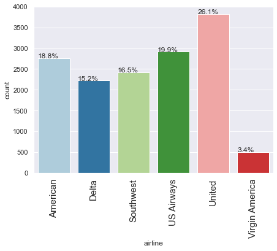

```python
labeled_barplot(tweetsdf1,'airline',perc=True)
```

Highest number of tweets are for United

#### Plot the distribution of sentiment across all the tweets

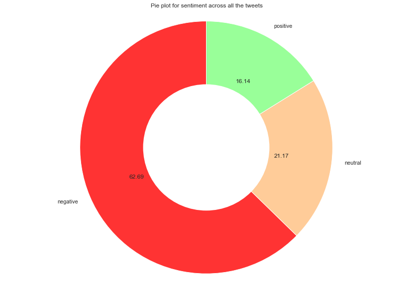

```python
#Using matplotlib
colors = ['#ff3333', '#ffcc99', '#99ff99']

sns.set(rc={'figure.figsize':(11.7,8.27)})
plot = plt.pie(tweetsdf1['airline_sentiment'].value_counts(), labels=tweetsdf1['airline_sentiment'].value_counts().index, colors=colors, startangle=90,  autopct='%.2f')
centre_circle = plt.Circle((0,0),0.5,color='black', fc='white',linewidth=0)
fig = plt.gcf()
fig.gca().add_artist(centre_circle)
plt.title('Pie plot for sentiment across all the tweets')
plt.axis('equal')
plt.tight_layout()
plt.show()
```

Almost 63% of tweets have negative sentiments

#### Plot the distribution of Sentiment of tweets for each airline

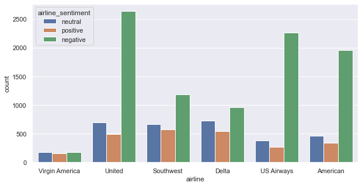

```python
plt.figure(figsize=(10, 5))
sns.countplot(x="airline", hue="airline_sentiment", data=tweetsdf1)
# plot to assess important variables
```

United, US Airways and American airlines have highest percentage of negative reviews

#### Plot the distribution of all the negative reasons

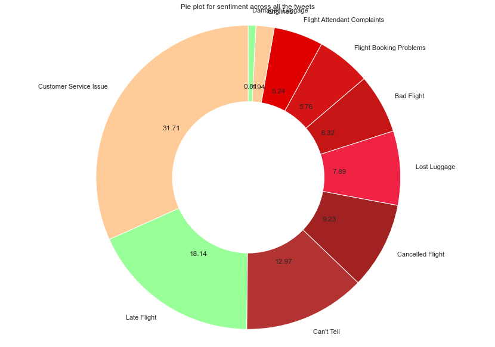

```python
#Using matplotlib
colors = [ '#ffcc99', '#99ff99', '#b33333', '#a22222', '#f12345', '#c51515', '#d51515', '#e00000']

sns.set(rc={'figure.figsize':(11.7,8.27)})
plot = plt.pie(tweetsdf1['negativereason'].value_counts(), labels=tweetsdf1['negativereason'].value_counts().index, colors=colors, startangle=90,  autopct='%.2f')
centre_circle = plt.Circle((0,0),0.5,color='black', fc='white',linewidth=0)
fig = plt.gcf()
fig.gca().add_artist(centre_circle)
plt.title('Pie plot for sentiment across all the tweets')
plt.axis('equal')
plt.tight_layout()
plt.show()
```

Highest number of negative tweets are about Customer Service and Late Flights

#### Plot the word cloud graph of tweets for positive sentiment

```python
from wordcloud import WordCloud,STOPWORDS
```

```python
positive_tweets=tweetsdf1[tweetsdf1['airline_sentiment']=='positive']
words = ' '.join(positive_tweets['text'])
cleaned_word = " ".join([word for word in words.split()
                            if 'http' not in word
                                and not word.startswith('@')
                                and word != 'RT'
                            ])
```

```python
wordcloud = WordCloud(stopwords=STOPWORDS,
                      background_color='black',
                      width=3000,
                      height=2500
                     ).generate(cleaned_word)
```

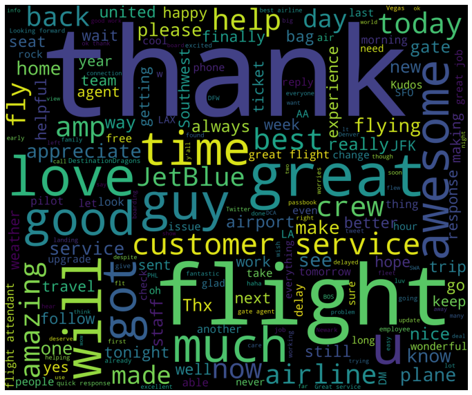

```python
plt.figure(1,figsize=(12, 12))
plt.imshow(wordcloud)
plt.axis('off')
plt.show()
```

Thank is the highest used word in positive tweet.

#### Plot the word cloud graph of tweets for negative sentiment

```python
negative_tweets=tweetsdf1[tweetsdf1['airline_sentiment']=='negative']
words = ' '.join(negative_tweets['text'])
cleaned_word = " ".join([word for word in words.split()
                            if 'http' not in word
                                and not word.startswith('@')
                                and word != 'RT'
                            ])
```

```python
wordcloud = WordCloud(stopwords=STOPWORDS,
                      background_color='black',
                      width=3000,
                      height=2500
                     ).generate(cleaned_word)
```

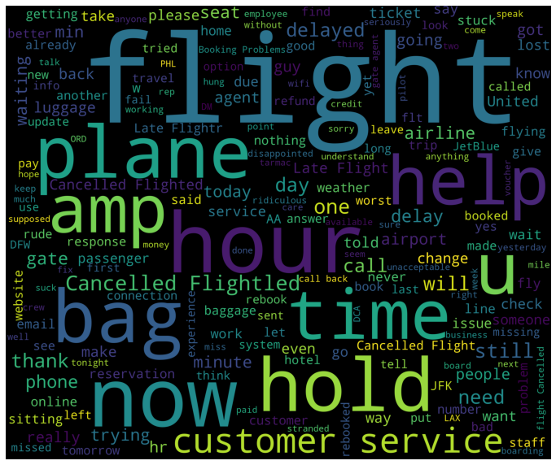

```python
plt.figure(1,figsize=(12, 12))
plt.imshow(wordcloud)
plt.axis('off')
plt.show()
```

Most used word in negative tweets is flight.

#### Insights based on EDA

1. Highest number of tweets are for United
2. Almost 63% of tweets have negative sentiments
3. United, US Airways and American airlines have highest percentage of negative reviews
4. Thank is the highest used word in positive tweet.
5. Most used word in negative tweets is flight.

### Understanding of Data Columns

#### Dropping all column except "text" and "airline_sentiments"

```python
tweetsdf2 = tweetsdf1[["text","airline_sentiment"]]
```

```python
print(
    f"There are {tweetsdf2.shape[0]} rows and {tweetsdf2.shape[1]} columns."
)  # f-string
```

```
There are 14640 rows and 2 columns.
```

```python
pd.set_option('display.max_colwidth', None) # Display full dataframe information (Non-turncated Text column.)

tweetsdf2.head()
```

|  | text | airline_sentiment |
| --- | --- | --- |
| 0 | @VirginAmerica What @dhepburn said. | neutral |
| 1 | @VirginAmerica plus you've added commercials to the experience... tacky. | positive |
| 2 | @VirginAmerica I didn't today... Must mean I need to take another trip! | neutral |
| 3 | @VirginAmerica it's really aggressive to blast obnoxious "entertainment" in your guests' faces &amp; they have little recourse | negative |
| 4 | @VirginAmerica and it's a really big bad thing about it | negative |

### Data Pre-Processing

#### Text pre-processing: Data preparation

```python
#remove the html tags
def strip_html(text):
    soup = BeautifulSoup(text, "html.parser")
    return soup.get_text()

#expand the contractions
def replace_contractions(text):
    """Replace contractions in string of text"""
    return contractions.fix(text)

#remove the numericals present in the text
def remove_numbers(text):
  text = re.sub(r'\d+', '', text)
  return text

# remove the url's present in the text
def remove_url(text):
    text = re.sub('http[s]?://(?:[a-zA-Z]|[0-9]|[$-_@.&+]|[!*\(\),]|(?:%[0-9a-fA-F][0-9a-fA-F]))+','',text)
    return text

# remove the mentions in the tweets
def remove_mention(text):
    text = re.sub(r'@\w+','',text)
    return text

def clean_text(text):
    text = strip_html(text)
    text = replace_contractions(text)
    text = remove_numbers(text)
    text = remove_url(text)
    text = remove_mention(text)
    return text
tweetsdf2['text'] = tweetsdf2['text'].apply(lambda x: clean_text(x))
tweetsdf2.head()
```

|  | text | airline_sentiment |
| --- | --- | --- |
| 0 | What said. | neutral |
| 1 | plus you have added commercials to the experience... tacky. | positive |
| 2 | I did not today... Must mean I need to take another trip! | neutral |
| 3 | it is really aggressive to blast obnoxious "entertainment" in your guests' faces & they have little recourse | negative |
| 4 | and it is a really big bad thing about it | negative |

```python
tweetsdf2['text'] = tweetsdf2.apply(lambda row: nltk.word_tokenize(row['text']), axis=1) # Tokenization of data
tweetsdf2.head()
```

|  | text | airline_sentiment |
| --- | --- | --- |
| 0 | [What, said, .] | neutral |
| 1 | [plus, you, have, added, commercials, to, the, experience, ..., tacky, .] | positive |
| 2 | [I, did, not, today, ..., Must, mean, I, need, to, take, another, trip, !] | neutral |
| 3 | [it, is, really, aggressive, to, blast, obnoxious, ``, entertainment, '', in, your, guests, ', faces, &, they, have, little, recourse] | negative |
| 4 | [and, it, is, a, really, big, bad, thing, about, it] | negative |

```python
import nltk
nltk.download('stopwords')
```

```
True
```

```python
stopwords = stopwords.words('english')
stopwords = list(set(stopwords))
lemmatizer = WordNetLemmatizer()

#remove the non-ASCII characters
def remove_non_ascii(words):
    """Remove non-ASCII characters from list of tokenized words"""
    new_words = []
    for word in words:
        new_word = unicodedata.normalize('NFKD', word).encode('ascii', 'ignore').decode('utf-8', 'ignore')
        new_words.append(new_word)
    return new_words

# convert all characters to lowercase
def to_lowercase(words):
    """Convert all characters to lowercase from list of tokenized words"""
    new_words = []
    for word in words:
        new_word = word.lower()
        new_words.append(new_word)
    return new_words


# Remove the hashtags
def remove_hash(text):
   """Remove hashtags from list of tokenized words"""
   new_words = []
   for word in words:
     new_word = re.sub(r'#\w+','',word)
     if new_word != '':
       new_words.append(new_word)
   return new_words

# Remove the punctuations
def remove_punctuation(words):
    """Remove punctuation from list of tokenized words"""
    new_words = []
    for word in words:
        new_word = re.sub(r'[^\w\s]', '', word)
        if new_word != '':
            new_words.append(new_word)
    return new_words

# Remove the stop words
def remove_stopwords(words):
    """Remove stop words from list of tokenized words"""
    new_words = []
    for word in words:
        if word not in stopwords:
            new_words.append(word)
    return new_words

# lemmatize the words
def lemmatize_list(words):
    new_words = []
    for word in words:
      new_words.append(lemmatizer.lemmatize(word, pos='v'))
    return new_words

def normalize(words):
    words = remove_non_ascii(words)
    words = to_lowercase(words)
    words = remove_punctuation(words)
    words = remove_stopwords(words)
    words = lemmatize_list(words)
    return ' '.join(words)

tweetsdf2['text'] = tweetsdf2.apply(lambda row: normalize(row['text']), axis=1)
```

```python
tweetsdf2.head()
```

|  | text | airline_sentiment |
| --- | --- | --- |
| 0 | say | neutral |
| 1 | plus add commercials experience tacky | positive |
| 2 | today must mean need take another trip | neutral |
| 3 | really aggressive blast obnoxious entertainment guests face little recourse | negative |
| 4 | really big bad thing | negative |

#### BAG of Words

```python
Count_vec = CountVectorizer(max_features=500)                # Keep only 500 features as number of features will increase the processing time.
data_features = Count_vec.fit_transform(tweetsdf2['text'])

data_features = data_features.toarray()                        # Convert the data features to array.
```

```python
data_features.shape       #Shape of the feature vector
```

```
(14640, 500)
```

```python
X = data_features

y = tweetsdf2.airline_sentiment
```

```python
# Split data into training and testing set.

from sklearn.model_selection import train_test_split

X_train, X_test, y_train, y_test = train_test_split(X, y, test_size=0.25, shuffle=False)
```

```python
# Finding optimal number of base learners using k-fold CV ->
base_ln = np.arange(100,400,100).tolist()
base_ln
```

```
[100, 200, 300]
```

```python
# K-Fold Cross - validation .
cv_scores = []
for b in base_ln:
    clf = RandomForestClassifier(n_estimators = b)
    scores = cross_val_score(clf, X_train, y_train, cv = 5, scoring = 'accuracy')
    cv_scores.append(scores.mean())
```

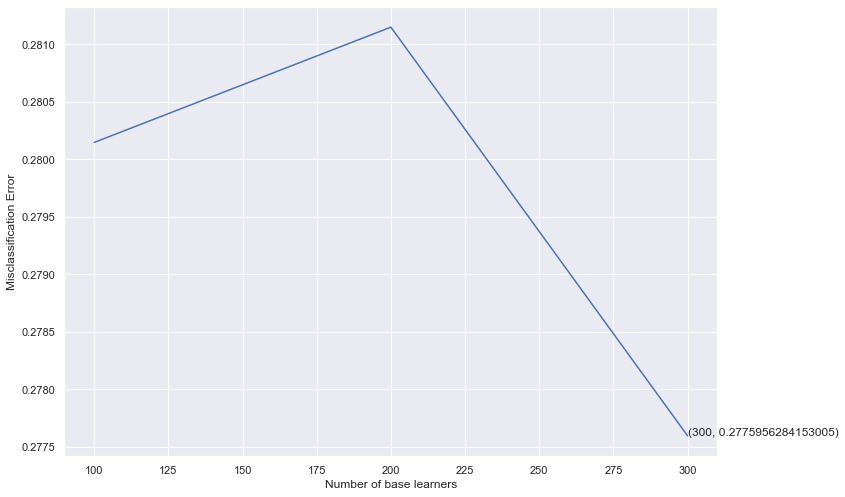

```python
# plotting the error as k increases
error = [1 - x for x in cv_scores]                                 #error corresponds to each nu of estimator
optimal_learners = base_ln[error.index(min(error))]                #Selection of optimal nu of n_estimator corresponds to minimum error.
plt.plot(base_ln, error)                                           #Plot between each nu of estimator and misclassification error
xy = (optimal_learners, min(error))
plt.annotate('(%s, %s)' % xy, xy = xy, textcoords='data')
plt.xlabel("Number of base learners")
plt.ylabel("Misclassification Error")
plt.show()
```

```python
# Training the best model and calculating accuracy on test data .
clf = RandomForestClassifier(n_estimators = optimal_learners)
clf.fit(X_train, y_train)
clf.score(X_test, y_test)
count_vectorizer_predicted = clf.predict(X_test)
print(classification_report(y_test ,count_vectorizer_predicted , target_names = ['positive' , 'negative', 'neutral']))
print("Accuracy of the model is : ",accuracy_score(y_test,count_vectorizer_predicted))
```

```
              precision    recall  f1-score   support

    positive       0.85      0.91      0.88      2627
    negative       0.54      0.42      0.47       577
     neutral       0.66      0.61      0.64       456

    accuracy                           0.79      3660
   macro avg       0.68      0.65      0.66      3660
weighted avg       0.78      0.79      0.78      3660

Accuracy of the model is :  0.7923497267759563
```

```
thank,flight,great,delay,love,get,awesome,cancel,hours,bag,hold,fly,best,amaze,please,hour,service,time,make,would,wait,need,fleek,help,go,good,know,plane,customer,call,dm,airline,follow,fleet,still,tomorrow,say,worst,us,like,
```

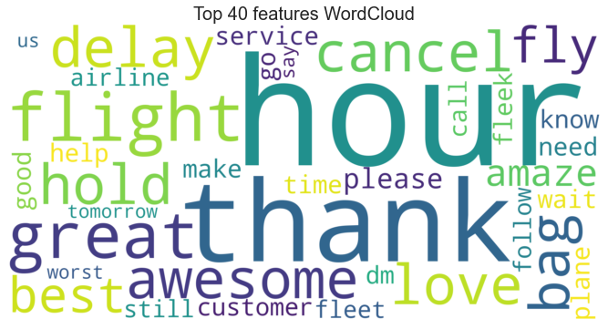

```python
all_features = Count_vec.get_feature_names()              #Instantiate the feature from the vectorizer
top_features=''                                            # Addition of top 40 feature into top_feature after training the model
feat=clf.feature_importances_
features=np.argsort(feat)[::-1]
for i in features[0:40]:
    top_features+=all_features[i]
    top_features+=','

print(top_features)

print(" ")
print(" ")

from wordcloud import WordCloud
wordcloud = WordCloud(background_color="white",colormap='viridis',width=2000,
                          height=1000).generate(top_features)

# Display the generated image:
plt.imshow(wordcloud, interpolation='bilinear')
plt.figure(1, figsize=(14, 11), frameon='equal')
plt.title('Top 40 features WordCloud', fontsize=20)
plt.axis("off")
plt.show()
```

### Tuning model to improve accuracy

```python
Count_vec = CountVectorizer(max_features=750)                # Keep only 500 features as number of features will increase the processing time.
data_features = Count_vec.fit_transform(tweetsdf2['text'])

data_features = data_features.toarray()
```

```python
data_features.shape       #Shape of the feature vector
```

```
(14640, 750)
```

```python
X = data_features
y = tweetsdf2.airline_sentiment
```

```python
X_train, X_test, y_train, y_test = train_test_split(X, y, test_size=0.30, shuffle=False)
```

```python
# Finding optimal number of base learners using k-fold CV ->
base_ln = np.arange(150,500,150).tolist()
base_ln
```

```
[150, 300, 450]
```

```python
# K-Fold Cross - validation .
cv_scores = []
for b in base_ln:
    clf = RandomForestClassifier(n_estimators = b)
    scores = cross_val_score(clf, X_train, y_train, cv = 6, scoring = 'accuracy')
    cv_scores.append(scores.mean())
```

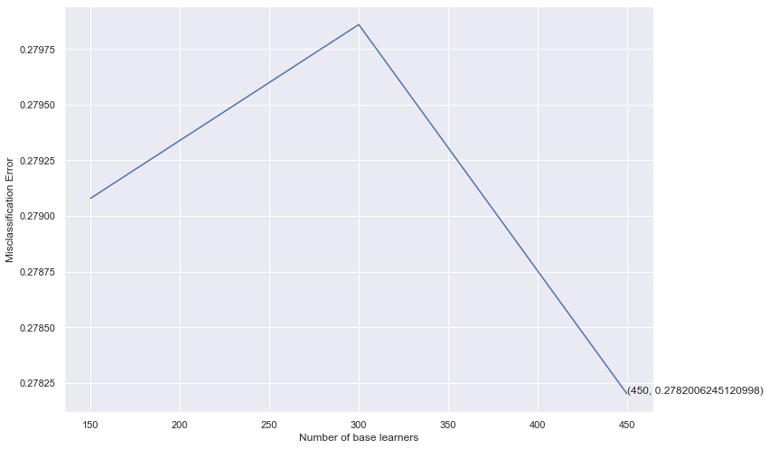

```python
# plotting the error as k increases
error = [1 - x for x in cv_scores]                                 #error corresponds to each nu of estimator
optimal_learners = base_ln[error.index(min(error))]                #Selection of optimal nu of n_estimator corresponds to minimum error.
plt.plot(base_ln, error)                                           #Plot between each nu of estimator and misclassification error
xy = (optimal_learners, min(error))
plt.annotate('(%s, %s)' % xy, xy = xy, textcoords='data')
plt.xlabel("Number of base learners")
plt.ylabel("Misclassification Error")
plt.show()
```

```python
# Training the best model and calculating accuracy on test data .
clf = RandomForestClassifier(n_estimators = optimal_learners)
clf.fit(X_train, y_train)
clf.score(X_test, y_test)
count_vectorizer_predicted = clf.predict(X_test)
print(classification_report(y_test ,count_vectorizer_predicted , target_names = ['positive' , 'negative', 'neutral']))
print("Accuracy of the model is : ",accuracy_score(y_test,count_vectorizer_predicted))
```

```
              precision    recall  f1-score   support

    positive       0.87      0.86      0.87      3200
    negative       0.47      0.47      0.47       672
     neutral       0.61      0.65      0.63       520

    accuracy                           0.78      4392
   macro avg       0.65      0.66      0.66      4392
weighted avg       0.78      0.78      0.78      4392

Accuracy of the model is :  0.7784608378870674
```

```
route,error,fix,control,international,file,attendant,fuck,blame,assist,excellent,free,automate,already,months,look,spend,system,frustrate,san,ppl,job,entire,enough,concern,hello,find,ago,force,first,excite,customers,money,switch,bite,platinum,lose,hrs,poor,info,
```

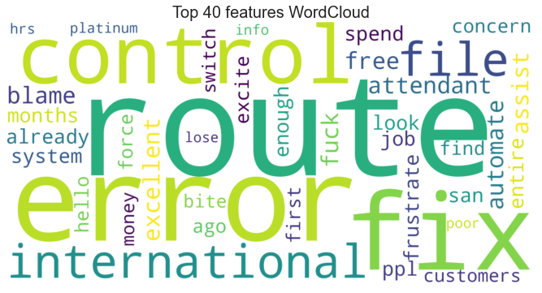

```python
all_features = Count_vec.get_feature_names()              #Instantiate the feature from the vectorizer
top_features=''                                            # Addition of top 40 feature into top_feature after training the model
feat=clf.feature_importances_
features=np.argsort(feat)[::-1]
for i in features[0:40]:
    top_features+=all_features[i]
    top_features+=','

print(top_features)

print(" ")
print(" ")

from wordcloud import WordCloud
wordcloud = WordCloud(background_color="white",colormap='viridis',width=2000,
                          height=1000).generate(top_features)

# Display the generated image:
plt.imshow(wordcloud, interpolation='bilinear')
plt.figure(1, figsize=(14, 11), frameon='equal')
plt.title('Top 40 features WordCloud', fontsize=20)
plt.axis("off")
plt.show()
```

### **TF-IDF** Vectorizer

```python
tfidf_vect = TfidfVectorizer(max_features=500)
data_features = tfidf_vect.fit_transform(tweetsdf2['text'])

data_features = data_features.toarray()

data_features.shape     #feature shape
```

```
(14640, 500)
```

```python
X = data_features
y = tweetsdf2.airline_sentiment
```

```python
X_train, X_test, y_train, y_test = train_test_split(X, y, test_size=0.25, shuffle=False)
```

```python
# Finding optimal number of base learners using k-fold CV ->
base_ln = np.arange(100,400,100).tolist()
base_ln
```

```
[100, 200, 300]
```

```python
# K-Fold Cross - validation .
cv_scores = []
for b in base_ln:
    clf = RandomForestClassifier(n_estimators = b)
    scores = cross_val_score(clf, X_train, y_train, cv = 5, scoring = 'accuracy')
    cv_scores.append(scores.mean())
```

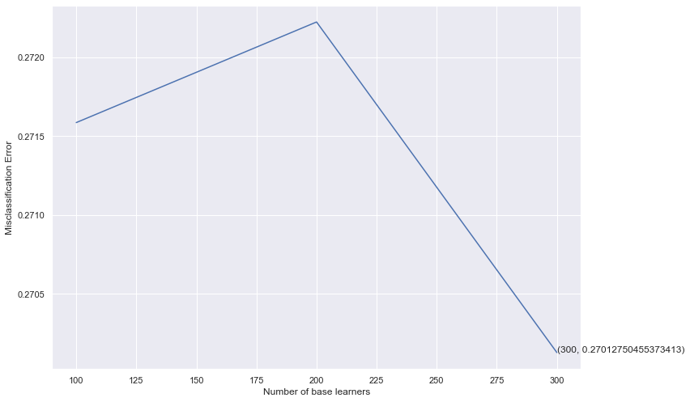

```python
# plotting the error as k increases
error = [1 - x for x in cv_scores]                                 #error corresponds to each nu of estimator
optimal_learners = base_ln[error.index(min(error))]                #Selection of optimal nu of n_estimator corresponds to minimum error.
plt.plot(base_ln, error)                                           #Plot between each nu of estimator and misclassification error
xy = (optimal_learners, min(error))
plt.annotate('(%s, %s)' % xy, xy = xy, textcoords='data')
plt.xlabel("Number of base learners")
plt.ylabel("Misclassification Error")
plt.show()
```

```python
# Training the best model and calculating accuracy on test data .
clf = RandomForestClassifier(n_estimators = optimal_learners)
clf.fit(X_train, y_train)
clf.score(X_test, y_test)
tf_idf_predicted = clf.predict(X_test)
print(classification_report(y_test , tf_idf_predicted , target_names = ['positive' , 'negative', 'neutral']))
print("Accuracy of the model is : ",accuracy_score(y_test,tf_idf_predicted))
```

```
              precision    recall  f1-score   support

    positive       0.85      0.91      0.88      2627
    negative       0.54      0.42      0.48       577
     neutral       0.67      0.63      0.65       456

    accuracy                           0.79      3660
   macro avg       0.69      0.65      0.67      3660
weighted avg       0.78      0.79      0.79      3660

Accuracy of the model is :  0.7945355191256831
```

```
thank, flight, great, delay, love, get, hours, awesome, bag, cancel, hold, fly, best, please, amaze, hour, service, make, time, wait, need, would, help, fleek, go, know, good, call, customer, dm, plane, airline, follow, still, tomorrow, fleet, say, worst, like, us,
```

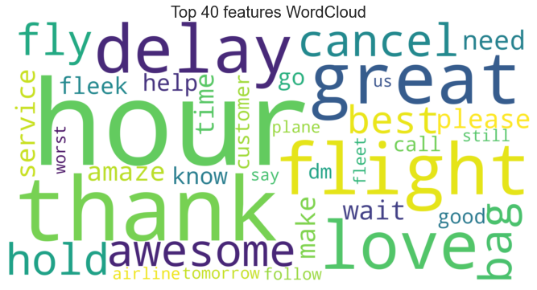

```python
all_features = tfidf_vect.get_feature_names()              #Instantiate the feature from the vectorizer
top_features=''                                            # Addition of top 40 feature into top_feature after training the model
feat=clf.feature_importances_
features=np.argsort(feat)[::-1]
for i in features[0:40]:
    top_features+=all_features[i]
    top_features+=', '

print(top_features)

print(" ")
print(" ")

from wordcloud import WordCloud
wordcloud = WordCloud(background_color="white",colormap='viridis',width=2000,
                          height=1000).generate(top_features)

# Display the generated image:
plt.imshow(wordcloud, interpolation='bilinear')
plt.figure(1, figsize=(14, 11), frameon='equal')
plt.title('Top 40 features WordCloud', fontsize=20)
plt.axis("off")
plt.show()
```

### Tuning model to improve accuracy

```python
tfidf_vect = TfidfVectorizer(max_features=650)
data_features = tfidf_vect.fit_transform(tweetsdf2['text'])

data_features = data_features.toarray()

data_features.shape     #feature shape
```

```
(14640, 650)
```

```python
X = data_features
y = tweetsdf2.airline_sentiment
```

```python
X_train, X_test, y_train, y_test = train_test_split(X, y, test_size=0.30, shuffle=False)
```

```python
# Finding optimal number of base learners using k-fold CV ->
base_ln = np.arange(200,500,200).tolist()
base_ln
```

```
[200, 400]
```

```python
# K-Fold Cross - validation .
cv_scores = []
for b in base_ln:
    clf = RandomForestClassifier(n_estimators = b)
    scores = cross_val_score(clf, X_train, y_train, cv = 6, scoring = 'accuracy')
    cv_scores.append(scores.mean())
```

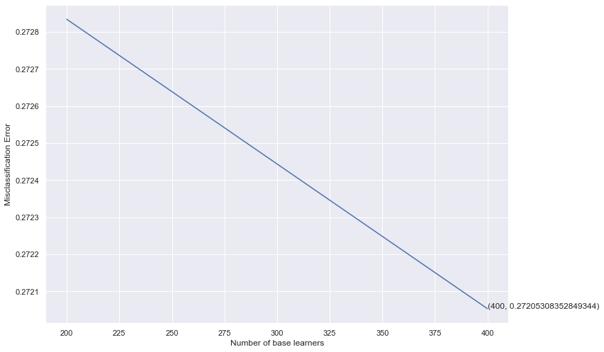

```python
# plotting the error as k increases
error = [1 - x for x in cv_scores]                                 #error corresponds to each nu of estimator
optimal_learners = base_ln[error.index(min(error))]                #Selection of optimal nu of n_estimator corresponds to minimum error.
plt.plot(base_ln, error)                                           #Plot between each nu of estimator and misclassification error
xy = (optimal_learners, min(error))
plt.annotate('(%s, %s)' % xy, xy = xy, textcoords='data')
plt.xlabel("Number of base learners")
plt.ylabel("Misclassification Error")
plt.show()
```

```python
# Training the best model and calculating accuracy on test data .
clf = RandomForestClassifier(n_estimators = optimal_learners)
clf.fit(X_train, y_train)
clf.score(X_test, y_test)
tf_idf_predicted = clf.predict(X_test)
print(classification_report(y_test , tf_idf_predicted , target_names = ['positive' , 'negative', 'neutral']))
print("Accuracy of the model is : ",accuracy_score(y_test,tf_idf_predicted))
```

```
              precision    recall  f1-score   support

    positive       0.86      0.91      0.88      3200
    negative       0.53      0.43      0.48       672
     neutral       0.67      0.63      0.65       520

    accuracy                           0.80      4392
   macro avg       0.69      0.66      0.67      4392
weighted avg       0.79      0.80      0.79      4392

Accuracy of the model is :  0.8005464480874317
```

```
thank, flight, great, delay, love, get, bag, hours, cancel, awesome, fly, hold, best, amaze, please, need, wait, would, hour, time, service, make, fleet, fleek, customer, know, go, airline, help, good, follow, dm, plane, worst, call, say, never, like, send, lose,
```

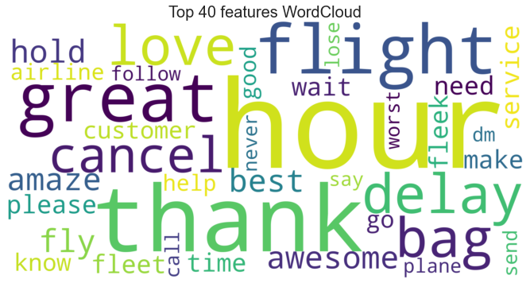

```python
all_features = tfidf_vect.get_feature_names()              #Instantiate the feature from the vectorizer
top_features=''                                            # Addition of top 40 feature into top_feature after training the model
feat=clf.feature_importances_
features=np.argsort(feat)[::-1]
for i in features[0:40]:
    top_features+=all_features[i]
    top_features+=', '

print(top_features)

print(" ")
print(" ")

from wordcloud import WordCloud
wordcloud = WordCloud(background_color="white",colormap='viridis',width=2000,
                          height=1000).generate(top_features)

# Display the generated image:
plt.imshow(wordcloud, interpolation='bilinear')
plt.figure(1, figsize=(14, 11), frameon='equal')
plt.title('Top 40 features WordCloud', fontsize=20)
plt.axis("off")
plt.show()
```

# **Conclusions**

1. Highest number of tweets are for United
2. Almost 63% of tweets have negative sentiments
3. United, US Airways and American airlines have highest percentage of negative reviews
4. Thank is the highest used word in positive tweet.
5. Most used word in negative tweets is flight
6. Accuracy and F1 Score is better for TF-IDF Vectorizer
7. After tuning the best accuracy score of 80% achieved for model 2 of TF-IDF